# Annual pension returns analysis

Martin Hoshi Vognsen

07:27 24 June 2026

# Summary

*Role of this report.* This annual report is an artifact, not the substance of the study. Its purpose is to show how far inference degrades when only annual data is available. Annual returns are too sparse to estimate the distribution, so the report goes no further than establishing that. The substance of the study is the monthly report, and the decision companion is the investor tool.

This is a **case study on a deliberately frozen data set** (annual returns 2011-2023), not an up-to-date monitor. Fixing the data is what lets us interpret a specific set of numbers and graphs. Three findings stand out.

1. **The “plans” are leverage levels on one portfolio, not distinct asset mixes.** Within each provider the high-risk plan is almost exactly a scalar multiple of the medium-risk plan ($\beta \approx 1.2$ for Velliv, $\approx 1.6$ for PFA, intercept $\approx 0$), and a single common factor explains about 96% of the variation across all four plans. PFA’s own product description confirms it: profiles B and D are fixed weighted blends of the *same two* underlying funds.
2. **“Risk” here means deeper drawdowns and start-date-dependent path ordering, not a different kind of bet.** The high-risk plan amplifies the same factor in both directions: it loses more in bad years (it underperformed the medium plan in 3-4 of 13 years), and its cumulative path drops below the medium plan’s whenever the index is started just before a drawdown.
3. **The sample is far too short to estimate the tail, and – at annual resolution – it contains no crash**, so every risk number is both barely identified and optimistically biased. For *precise* tail estimates the honest verdict is close to Taleb’s “better stay home”; what survives is the *qualitative* structure – fat tails, leverage, and asymmetric drawdowns.

The Discussion at the end develops these points.

# Returns data 2011-2023.

Fit log returns to F-S skew standardized Student-t distribution. `m` is the location parameter. `s` is the scale parameter. `nu` is the estimated shape parameter (degrees of freedom). `xi` is the estimated skewness parameter.

For 2011, medium risk data is used in the high risk data set, as no high risk fund data is available prior to 2012.  
`vmrl` is a long version of Velliv medium risk data, from 2007 to 2023. For 2007 to 2011 (both included) no high risk data is available.

PFA medium risk is risk profile B.  
PFA high risk is risk profile D.

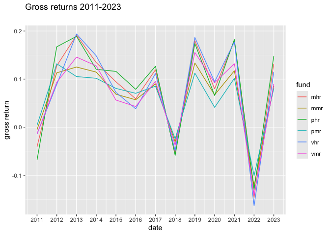

## Summary of log-returns

The summary statistics are transformed back to the scale of gross returns by taking $exp()$ of each summary statistic. (Note: Taking arithmetic mean of gross returns directly is no good. Must be geometric mean.)

|  | vmr | vhr | vmrl | pmr | phr | mmr | mhr | vmr_phr | vhr_pmr |
| --- | --- | --- | --- | --- | --- | --- | --- | --- | --- |
| Min. : | 0.868 | 0.849 | 0.801 | 0.904 | 0.878 | 0.885 | 0.864 | 0.874 | 0.873 |
| 1st Qu.: | 1.044 | 1.039 | 1.013 | 1.042 | 1.068 | 1.059 | 1.061 | 1.064 | 1.055 |
| Median : | 1.097 | 1.099 | 1.085 | 1.084 | 1.128 | 1.089 | 1.127 | 1.119 | 1.104 |
| Mean : | 1.067 | 1.080 | 1.057 | 1.063 | 1.089 | 1.065 | 1.085 | 1.079 | 1.072 |
| 3rd Qu.: | 1.136 | 1.160 | 1.128 | 1.107 | 1.182 | 1.121 | 1.144 | 1.139 | 1.134 |
| Max. : | 1.168 | 1.214 | 1.193 | 1.141 | 1.208 | 1.143 | 1.211 | 1.183 | 1.163 |

## Ranking

| Min. : | ranking | 1st Qu.: | ranking | Median : | ranking | Mean : | ranking | 3rd Qu.: | ranking | Max. : | ranking |
| --- | --- | --- | --- | --- | --- | --- | --- | --- | --- | --- | --- |
| 0.904 | pmr | 1.068 | phr | 1.128 | phr | 1.089 | phr | 1.182 | phr | 1.214 | vhr |
| 0.885 | mmr | 1.064 | vmr_phr | 1.127 | mhr | 1.085 | mhr | 1.160 | vhr | 1.211 | mhr |
| 0.878 | phr | 1.061 | mhr | 1.119 | vmr_phr | 1.080 | vhr | 1.144 | mhr | 1.208 | phr |
| 0.874 | vmr_phr | 1.059 | mmr | 1.104 | vhr_pmr | 1.079 | vmr_phr | 1.139 | vmr_phr | 1.193 | vmrl |
| 0.873 | vhr_pmr | 1.055 | vhr_pmr | 1.099 | vhr | 1.072 | vhr_pmr | 1.136 | vmr | 1.183 | vmr_phr |
| 0.868 | vmr | 1.044 | vmr | 1.097 | vmr | 1.067 | vmr | 1.134 | vhr_pmr | 1.168 | vmr |
| 0.864 | mhr | 1.042 | pmr | 1.089 | mmr | 1.065 | mmr | 1.128 | vmrl | 1.163 | vhr_pmr |
| 0.849 | vhr | 1.039 | vhr | 1.085 | vmrl | 1.063 | pmr | 1.121 | mmr | 1.143 | mmr |
| 0.801 | vmrl | 1.013 | vmrl | 1.084 | pmr | 1.057 | vmrl | 1.107 | pmr | 1.141 | pmr |

## Correlations and covariance

Correlations

|  | vmr | vhr | pmr | phr |
| --- | --- | --- | --- | --- |
| vmr | 1.000 | 0.993 | 0.938 | 0.941 |
| vhr | 0.993 | 1.000 | 0.917 | 0.939 |
| pmr | 0.938 | 0.917 | 1.000 | 0.957 |
| phr | 0.941 | 0.939 | 0.957 | 1.000 |

Covariances

|  | vmr | vhr | pmr | phr |
| --- | --- | --- | --- | --- |
| vmr | 0.007 | 0.009 | 0.005 | 0.008 |
| vhr | 0.009 | 0.011 | 0.006 | 0.010 |
| pmr | 0.005 | 0.006 | 0.004 | 0.007 |
| phr | 0.008 | 0.010 | 0.007 | 0.011 |

# Compare pension plans

## Risk of loss

Risk of loss at least as big as row name in percent for a single period (year).

Skewed $t$-distribution (sstd):

|  | vmr | vhr | pmr | phr | mmr | mhr | vmr_phr | vhr_pmr |
| --- | --- | --- | --- | --- | --- | --- | --- | --- |
| 0 | 17.167 | 19.667 | 11.833 | 16.000 | 16.667 | 17.000 | 15.000 | 14.500 |
| 5 | 9.167 | 12.500 | 5.667 | 9.333 | 8.500 | 10.500 | 8.667 | 7.333 |
| 10 | 5.000 | 8.000 | 3.000 | 5.333 | 4.500 | 6.500 | 5.000 | 3.833 |
| 25 | 0.667 | 2.167 | 0.500 | 0.833 | 0.667 | 1.667 | 1.000 | 0.333 |
| 50 | 0.000 | 0.000 | 0.000 | 0.000 | 0.000 | 0.000 | 0.000 | 0.000 |
| 90 | 0.000 | 0.000 | 0.000 | 0.000 | 0.000 | 0.000 | 0.000 | 0.000 |
| 99 | 0.000 | 0.000 | 0.000 | 0.000 | 0.000 | 0.000 | 0.000 | 0.000 |

Standardized $t$-distribution (std):

|  | vmr | vhr | pmr | phr | mmr | mhr | vmr_phr | vhr_pmr |
| --- | --- | --- | --- | --- | --- | --- | --- | --- |
| 0 | 10.500 | 16.167 | 5.500 | 8.500 | 7.000 | 20.167 | 8.000 | 8.500 |
| 5 | 4.167 | 6.833 | 2.167 | 4.500 | 3.000 | 8.667 | 4.000 | 3.667 |
| 10 | 1.667 | 2.500 | 1.000 | 2.667 | 1.500 | 2.500 | 2.167 | 1.667 |
| 25 | 0.000 | 0.000 | 0.000 | 0.500 | 0.167 | 0.000 | 0.333 | 0.000 |
| 50 | 0.000 | 0.000 | 0.000 | 0.000 | 0.000 | 0.000 | 0.000 | 0.000 |
| 90 | 0.000 | 0.000 | 0.000 | 0.000 | 0.000 | 0.000 | 0.000 | 0.000 |
| 99 | 0.000 | 0.000 | 0.000 | 0.000 | 0.000 | 0.000 | 0.000 | 0.000 |

Normal distribution:

|  | vmr | vhr | pmr | phr | mmr | mhr | vmr_phr | vhr_pmr |
| --- | --- | --- | --- | --- | --- | --- | --- | --- |
| 0 | 21.167 | 21.667 | 16.500 | 19.667 | 18.667 | 20.167 | 19.833 | 19.167 |
| 5 | 7.333 | 9.500 | 3.333 | 8.500 | 5.167 | 8.667 | 7.667 | 6.333 |
| 10 | 1.500 | 2.833 | 0.000 | 2.667 | 0.500 | 2.500 | 1.833 | 1.167 |
| 25 | 0.000 | 0.000 | 0.000 | 0.000 | 0.000 | 0.000 | 0.000 | 0.000 |
| 50 | 0.000 | 0.000 | 0.000 | 0.000 | 0.000 | 0.000 | 0.000 | 0.000 |
| 90 | 0.000 | 0.000 | 0.000 | 0.000 | 0.000 | 0.000 | 0.000 | 0.000 |
| 99 | 0.000 | 0.000 | 0.000 | 0.000 | 0.000 | 0.000 | 0.000 | 0.000 |

### Worst ranking for loss percentiles

Skewed $t$-distribution (sstd):

| 0 | ranking | 5 | ranking | 10 | ranking | 25 | ranking | 50 | ranking | 90 | ranking | 99 | ranking |
| --- | --- | --- | --- | --- | --- | --- | --- | --- | --- | --- | --- | --- | --- |
| 19.667 | vhr | 12.500 | vhr | 8.000 | vhr | 2.167 | vhr | 0 | vmr | 0 | vmr | 0 | vmr |
| 17.167 | vmr | 10.500 | mhr | 6.500 | mhr | 1.667 | mhr | 0 | vhr | 0 | vhr | 0 | vhr |
| 17.000 | mhr | 9.333 | phr | 5.333 | phr | 1.000 | vmr_phr | 0 | pmr | 0 | pmr | 0 | pmr |
| 16.667 | mmr | 9.167 | vmr | 5.000 | vmr | 0.833 | phr | 0 | phr | 0 | phr | 0 | phr |
| 16.000 | phr | 8.667 | vmr_phr | 5.000 | vmr_phr | 0.667 | vmr | 0 | mmr | 0 | mmr | 0 | mmr |
| 15.000 | vmr_phr | 8.500 | mmr | 4.500 | mmr | 0.667 | mmr | 0 | mhr | 0 | mhr | 0 | mhr |
| 14.500 | vhr_pmr | 7.333 | vhr_pmr | 3.833 | vhr_pmr | 0.500 | pmr | 0 | vmr_phr | 0 | vmr_phr | 0 | vmr_phr |
| 11.833 | pmr | 5.667 | pmr | 3.000 | pmr | 0.333 | vhr_pmr | 0 | vhr_pmr | 0 | vhr_pmr | 0 | vhr_pmr |

Standardized $t$-distribution (std):

| 0 | ranking | 5 | ranking | 10 | ranking | 25 | ranking | 50 | ranking | 90 | ranking | 99 | ranking |
| --- | --- | --- | --- | --- | --- | --- | --- | --- | --- | --- | --- | --- | --- |
| 20.167 | mhr | 8.667 | mhr | 2.667 | phr | 0.500 | phr | 0 | vmr | 0 | vmr | 0 | vmr |
| 16.167 | vhr | 6.833 | vhr | 2.500 | vhr | 0.333 | vmr_phr | 0 | vhr | 0 | vhr | 0 | vhr |
| 10.500 | vmr | 4.500 | phr | 2.500 | mhr | 0.167 | mmr | 0 | pmr | 0 | pmr | 0 | pmr |
| 8.500 | phr | 4.167 | vmr | 2.167 | vmr_phr | 0.000 | vmr | 0 | phr | 0 | phr | 0 | phr |
| 8.500 | vhr_pmr | 4.000 | vmr_phr | 1.667 | vmr | 0.000 | vhr | 0 | mmr | 0 | mmr | 0 | mmr |
| 8.000 | vmr_phr | 3.667 | vhr_pmr | 1.667 | vhr_pmr | 0.000 | pmr | 0 | mhr | 0 | mhr | 0 | mhr |
| 7.000 | mmr | 3.000 | mmr | 1.500 | mmr | 0.000 | mhr | 0 | vmr_phr | 0 | vmr_phr | 0 | vmr_phr |
| 5.500 | pmr | 2.167 | pmr | 1.000 | pmr | 0.000 | vhr_pmr | 0 | vhr_pmr | 0 | vhr_pmr | 0 | vhr_pmr |

Normal distribution:

| 0 | ranking | 5 | ranking | 10 | ranking | 25 | ranking | 50 | ranking | 90 | ranking | 99 | ranking |
| --- | --- | --- | --- | --- | --- | --- | --- | --- | --- | --- | --- | --- | --- |
| 21.667 | vhr | 9.500 | vhr | 2.833 | vhr | 0 | vmr | 0 | vmr | 0 | vmr | 0 | vmr |
| 21.167 | vmr | 8.667 | mhr | 2.667 | phr | 0 | vhr | 0 | vhr | 0 | vhr | 0 | vhr |
| 20.167 | mhr | 8.500 | phr | 2.500 | mhr | 0 | pmr | 0 | pmr | 0 | pmr | 0 | pmr |
| 19.833 | vmr_phr | 7.667 | vmr_phr | 1.833 | vmr_phr | 0 | phr | 0 | phr | 0 | phr | 0 | phr |
| 19.667 | phr | 7.333 | vmr | 1.500 | vmr | 0 | mmr | 0 | mmr | 0 | mmr | 0 | mmr |
| 19.167 | vhr_pmr | 6.333 | vhr_pmr | 1.167 | vhr_pmr | 0 | mhr | 0 | mhr | 0 | mhr | 0 | mhr |
| 18.667 | mmr | 5.167 | mmr | 0.500 | mmr | 0 | vmr_phr | 0 | vmr_phr | 0 | vmr_phr | 0 | vmr_phr |
| 16.500 | pmr | 3.333 | pmr | 0.000 | pmr | 0 | vhr_pmr | 0 | vhr_pmr | 0 | vhr_pmr | 0 | vhr_pmr |

## Chance of min gains

Chance of gains of at least `x` percent for a single period (year).  
`x` values are row names.

Skewed $t$-distribution (sstd):

|  | vmr | vhr | pmr | phr | mmr | mhr | vmr_phr | vhr_pmr |
| --- | --- | --- | --- | --- | --- | --- | --- | --- |
| 0 | 82.833 | 80.333 | 88.167 | 84.000 | 83.333 | 83.000 | 85.000 | 85.500 |
| 5 | 68.333 | 69.333 | 71.667 | 73.000 | 66.500 | 72.500 | 73.167 | 71.167 |
| 10 | 44.667 | 53.333 | 32.500 | 55.833 | 35.667 | 56.167 | 53.000 | 46.000 |
| 25 | 0.000 | 0.000 | 0.000 | 0.000 | 0.000 | 0.000 | 0.000 | 0.000 |
| 50 | 0.000 | 0.000 | 0.000 | 0.000 | 0.000 | 0.000 | 0.000 | 0.000 |
| 100 | 0.000 | 0.000 | 0.000 | 0.000 | 0.000 | 0.000 | 0.000 | 0.000 |

Standardized $t$-distribution (std):

|  | vmr | vhr | pmr | phr | mmr | mhr | vmr_phr | vhr_pmr |
| --- | --- | --- | --- | --- | --- | --- | --- | --- |
| 0 | 89.500 | 83.833 | 94.500 | 91.500 | 93.000 | 79.833 | 92.000 | 91.500 |
| 5 | 73.000 | 67.667 | 81.333 | 83.000 | 79.500 | 63.000 | 82.167 | 77.833 |
| 10 | 43.833 | 47.000 | 38.500 | 65.500 | 43.333 | 44.333 | 59.167 | 48.667 |
| 25 | 4.167 | 7.500 | 2.000 | 11.667 | 3.167 | 7.167 | 7.333 | 4.500 |
| 50 | 0.167 | 0.000 | 0.000 | 1.667 | 0.333 | 0.000 | 1.000 | 0.333 |
| 100 | 0.000 | 0.000 | 0.000 | 0.000 | 0.000 | 0.000 | 0.000 | 0.000 |

Normal distribution:

|  | vmr | vhr | pmr | phr | mmr | mhr | vmr_phr | vhr_pmr |
| --- | --- | --- | --- | --- | --- | --- | --- | --- |
| 0 | 78.833 | 78.333 | 83.500 | 80.333 | 81.333 | 79.833 | 80.167 | 80.833 |
| 5 | 57.667 | 61.333 | 57.667 | 64.167 | 57.833 | 63.000 | 61.833 | 60.167 |
| 10 | 35.167 | 42.500 | 29.000 | 46.167 | 32.167 | 44.333 | 41.333 | 37.167 |
| 25 | 2.167 | 6.667 | 0.000 | 8.333 | 0.833 | 7.167 | 4.833 | 2.333 |
| 50 | 0.000 | 0.000 | 0.000 | 0.000 | 0.000 | 0.000 | 0.000 | 0.000 |
| 100 | 0.000 | 0.000 | 0.000 | 0.000 | 0.000 | 0.000 | 0.000 | 0.000 |

### Best ranking for gains percentiles

Skewed $t$-distribution (sstd):

| 0 | ranking | 5 | ranking | 10 | ranking | 25 | ranking | 50 | ranking | 100 | ranking |
| --- | --- | --- | --- | --- | --- | --- | --- | --- | --- | --- | --- |
| 88.167 | pmr | 73.167 | vmr_phr | 56.167 | mhr | 0 | vmr | 0 | vmr | 0 | vmr |
| 85.500 | vhr_pmr | 73.000 | phr | 55.833 | phr | 0 | vhr | 0 | vhr | 0 | vhr |
| 85.000 | vmr_phr | 72.500 | mhr | 53.333 | vhr | 0 | pmr | 0 | pmr | 0 | pmr |
| 84.000 | phr | 71.667 | pmr | 53.000 | vmr_phr | 0 | phr | 0 | phr | 0 | phr |
| 83.333 | mmr | 71.167 | vhr_pmr | 46.000 | vhr_pmr | 0 | mmr | 0 | mmr | 0 | mmr |
| 83.000 | mhr | 69.333 | vhr | 44.667 | vmr | 0 | mhr | 0 | mhr | 0 | mhr |
| 82.833 | vmr | 68.333 | vmr | 35.667 | mmr | 0 | vmr_phr | 0 | vmr_phr | 0 | vmr_phr |
| 80.333 | vhr | 66.500 | mmr | 32.500 | pmr | 0 | vhr_pmr | 0 | vhr_pmr | 0 | vhr_pmr |

Standardized $t$-distribution (std):

| 0 | ranking | 5 | ranking | 10 | ranking | 25 | ranking | 50 | ranking | 100 | ranking |
| --- | --- | --- | --- | --- | --- | --- | --- | --- | --- | --- | --- |
| 94.500 | pmr | 83.000 | phr | 65.500 | phr | 11.667 | phr | 1.667 | phr | 0 | vmr |
| 93.000 | mmr | 82.167 | vmr_phr | 59.167 | vmr_phr | 7.500 | vhr | 1.000 | vmr_phr | 0 | vhr |
| 92.000 | vmr_phr | 81.333 | pmr | 48.667 | vhr_pmr | 7.333 | vmr_phr | 0.333 | mmr | 0 | pmr |
| 91.500 | phr | 79.500 | mmr | 47.000 | vhr | 7.167 | mhr | 0.333 | vhr_pmr | 0 | phr |
| 91.500 | vhr_pmr | 77.833 | vhr_pmr | 44.333 | mhr | 4.500 | vhr_pmr | 0.167 | vmr | 0 | mmr |
| 89.500 | vmr | 73.000 | vmr | 43.833 | vmr | 4.167 | vmr | 0.000 | vhr | 0 | mhr |
| 83.833 | vhr | 67.667 | vhr | 43.333 | mmr | 3.167 | mmr | 0.000 | pmr | 0 | vmr_phr |
| 79.833 | mhr | 63.000 | mhr | 38.500 | pmr | 2.000 | pmr | 0.000 | mhr | 0 | vhr_pmr |

Normal distribution:

| 0 | ranking | 5 | ranking | 10 | ranking | 25 | ranking | 50 | ranking | 100 | ranking |
| --- | --- | --- | --- | --- | --- | --- | --- | --- | --- | --- | --- |
| 83.500 | pmr | 64.167 | phr | 46.167 | phr | 8.333 | phr | 0 | vmr | 0 | vmr |
| 81.333 | mmr | 63.000 | mhr | 44.333 | mhr | 7.167 | mhr | 0 | vhr | 0 | vhr |
| 80.833 | vhr_pmr | 61.833 | vmr_phr | 42.500 | vhr | 6.667 | vhr | 0 | pmr | 0 | pmr |
| 80.333 | phr | 61.333 | vhr | 41.333 | vmr_phr | 4.833 | vmr_phr | 0 | phr | 0 | phr |
| 80.167 | vmr_phr | 60.167 | vhr_pmr | 37.167 | vhr_pmr | 2.333 | vhr_pmr | 0 | mmr | 0 | mmr |
| 79.833 | mhr | 57.833 | mmr | 35.167 | vmr | 2.167 | vmr | 0 | mhr | 0 | mhr |
| 78.833 | vmr | 57.667 | vmr | 32.167 | mmr | 0.833 | mmr | 0 | vmr_phr | 0 | vmr_phr |
| 78.333 | vhr | 57.667 | pmr | 29.000 | pmr | 0.000 | pmr | 0 | vhr_pmr | 0 | vhr_pmr |

## MC risk percentiles

Risk of loss at least as big as row name in percent from first to last period.

Skewed $t$-distribution (sstd):

|  | vmr | vhr | pmr | phr | mmr | mhr | vmr_phr | vhr_pmr |
| --- | --- | --- | --- | --- | --- | --- | --- | --- |
| 0 | 1.58 | 3.99 | 1.86 | 0.90 | 2.31 | 2.34 | 1.88 | 0.67 |
| 5 | 1.32 | 3.72 | 1.70 | 0.77 | 1.96 | 2.16 | 1.66 | 0.54 |
| 10 | 1.13 | 3.40 | 1.48 | 0.65 | 1.59 | 1.84 | 1.51 | 0.44 |
| 25 | 0.64 | 2.28 | 1.13 | 0.42 | 1.08 | 1.28 | 1.11 | 0.26 |
| 50 | 0.24 | 1.04 | 0.55 | 0.17 | 0.43 | 0.58 | 0.46 | 0.08 |
| 90 | 0.02 | 0.14 | 0.07 | 0.01 | 0.06 | 0.10 | 0.03 | 0.00 |
| 99 | 0.00 | 0.00 | 0.00 | 0.00 | 0.00 | 0.00 | 0.00 | 0.00 |

Standardized $t$-distribution (std):

|  | vmr | vhr | pmr | phr | mmr | mhr | vmr_phr | vhr_pmr |
| --- | --- | --- | --- | --- | --- | --- | --- | --- |
| 0 | 0.30 | 0 | 0.47 | 0.66 | 0.67 | 0.01 | 0.68 | 0.25 |
| 5 | 0.27 | 0 | 0.46 | 0.63 | 0.62 | 0.00 | 0.62 | 0.23 |
| 10 | 0.25 | 0 | 0.42 | 0.59 | 0.59 | 0.00 | 0.61 | 0.22 |
| 25 | 0.16 | 0 | 0.34 | 0.50 | 0.46 | 0.00 | 0.50 | 0.18 |
| 50 | 0.10 | 0 | 0.26 | 0.41 | 0.30 | 0.00 | 0.36 | 0.08 |
| 90 | 0.02 | 0 | 0.07 | 0.19 | 0.06 | 0.00 | 0.15 | 0.02 |
| 99 | 0.00 | 0 | 0.00 | 0.00 | 0.00 | 0.00 | 0.00 | 0.00 |

Normal distribution:

|  | vmr | vhr | pmr | phr | mmr | mhr | vmr_phr | vhr_pmr |
| --- | --- | --- | --- | --- | --- | --- | --- | --- |
| 0 | 0.02 | 0.05 | 0 | 0.02 | 0 | 0.02 | 0.02 | 0.02 |
| 5 | 0.02 | 0.04 | 0 | 0.02 | 0 | 0.02 | 0.01 | 0.01 |
| 10 | 0.02 | 0.02 | 0 | 0.01 | 0 | 0.00 | 0.01 | 0.01 |
| 25 | 0.00 | 0.00 | 0 | 0.01 | 0 | 0.00 | 0.00 | 0.00 |
| 50 | 0.00 | 0.00 | 0 | 0.00 | 0 | 0.00 | 0.00 | 0.00 |
| 90 | 0.00 | 0.00 | 0 | 0.00 | 0 | 0.00 | 0.00 | 0.00 |
| 99 | 0.00 | 0.00 | 0 | 0.00 | 0 | 0.00 | 0.00 | 0.00 |

### Worst ranking for MC loss percentiles

Skewed $t$-distribution (sstd):

| 0 | ranking | 5 | ranking | 10 | ranking | 25 | ranking | 50 | ranking | 90 | ranking | 99 | ranking |
| --- | --- | --- | --- | --- | --- | --- | --- | --- | --- | --- | --- | --- | --- |
| 3.99 | vhr | 3.72 | vhr | 3.40 | vhr | 2.28 | vhr | 1.04 | vhr | 0.14 | vhr | 0 | vmr |
| 2.34 | mhr | 2.16 | mhr | 1.84 | mhr | 1.28 | mhr | 0.58 | mhr | 0.10 | mhr | 0 | vhr |
| 2.31 | mmr | 1.96 | mmr | 1.59 | mmr | 1.13 | pmr | 0.55 | pmr | 0.07 | pmr | 0 | pmr |
| 1.88 | vmr_phr | 1.70 | pmr | 1.51 | vmr_phr | 1.11 | vmr_phr | 0.46 | vmr_phr | 0.06 | mmr | 0 | phr |
| 1.86 | pmr | 1.66 | vmr_phr | 1.48 | pmr | 1.08 | mmr | 0.43 | mmr | 0.03 | vmr_phr | 0 | mmr |
| 1.58 | vmr | 1.32 | vmr | 1.13 | vmr | 0.64 | vmr | 0.24 | vmr | 0.02 | vmr | 0 | mhr |
| 0.90 | phr | 0.77 | phr | 0.65 | phr | 0.42 | phr | 0.17 | phr | 0.01 | phr | 0 | vmr_phr |
| 0.67 | vhr_pmr | 0.54 | vhr_pmr | 0.44 | vhr_pmr | 0.26 | vhr_pmr | 0.08 | vhr_pmr | 0.00 | vhr_pmr | 0 | vhr_pmr |

Standardized $t$-distribution (std):

| 0 | ranking | 5 | ranking | 10 | ranking | 25 | ranking | 50 | ranking | 90 | ranking | 99 | ranking |
| --- | --- | --- | --- | --- | --- | --- | --- | --- | --- | --- | --- | --- | --- |
| 0.68 | vmr_phr | 0.63 | phr | 0.61 | vmr_phr | 0.50 | phr | 0.41 | phr | 0.19 | phr | 0 | vmr |
| 0.67 | mmr | 0.62 | mmr | 0.59 | phr | 0.50 | vmr_phr | 0.36 | vmr_phr | 0.15 | vmr_phr | 0 | vhr |
| 0.66 | phr | 0.62 | vmr_phr | 0.59 | mmr | 0.46 | mmr | 0.30 | mmr | 0.07 | pmr | 0 | pmr |
| 0.47 | pmr | 0.46 | pmr | 0.42 | pmr | 0.34 | pmr | 0.26 | pmr | 0.06 | mmr | 0 | phr |
| 0.30 | vmr | 0.27 | vmr | 0.25 | vmr | 0.18 | vhr_pmr | 0.10 | vmr | 0.02 | vmr | 0 | mmr |
| 0.25 | vhr_pmr | 0.23 | vhr_pmr | 0.22 | vhr_pmr | 0.16 | vmr | 0.08 | vhr_pmr | 0.02 | vhr_pmr | 0 | mhr |
| 0.01 | mhr | 0.00 | vhr | 0.00 | vhr | 0.00 | vhr | 0.00 | vhr | 0.00 | vhr | 0 | vmr_phr |
| 0.00 | vhr | 0.00 | mhr | 0.00 | mhr | 0.00 | mhr | 0.00 | mhr | 0.00 | mhr | 0 | vhr_pmr |

Normal distribution:

| 0 | ranking | 5 | ranking | 10 | ranking | 25 | ranking | 50 | ranking | 90 | ranking | 99 | ranking |
| --- | --- | --- | --- | --- | --- | --- | --- | --- | --- | --- | --- | --- | --- |
| 0.05 | vhr | 0.04 | vhr | 0.02 | vmr | 0.01 | phr | 0 | vmr | 0 | vmr | 0 | vmr |
| 0.02 | vmr | 0.02 | vmr | 0.02 | vhr | 0.00 | vmr | 0 | vhr | 0 | vhr | 0 | vhr |
| 0.02 | phr | 0.02 | phr | 0.01 | phr | 0.00 | vhr | 0 | pmr | 0 | pmr | 0 | pmr |
| 0.02 | mhr | 0.02 | mhr | 0.01 | vmr_phr | 0.00 | pmr | 0 | phr | 0 | phr | 0 | phr |
| 0.02 | vmr_phr | 0.01 | vmr_phr | 0.01 | vhr_pmr | 0.00 | mmr | 0 | mmr | 0 | mmr | 0 | mmr |
| 0.02 | vhr_pmr | 0.01 | vhr_pmr | 0.00 | pmr | 0.00 | mhr | 0 | mhr | 0 | mhr | 0 | mhr |
| 0.00 | pmr | 0.00 | pmr | 0.00 | mmr | 0.00 | vmr_phr | 0 | vmr_phr | 0 | vmr_phr | 0 | vmr_phr |
| 0.00 | mmr | 0.00 | mmr | 0.00 | mhr | 0.00 | vhr_pmr | 0 | vhr_pmr | 0 | vhr_pmr | 0 | vhr_pmr |

## MC gains percentiles

Skewed $t$-distribution (sstd):

|  | vmr | vhr | pmr | phr | mmr | mhr | vmr_phr | vhr_pmr |
| --- | --- | --- | --- | --- | --- | --- | --- | --- |
| 0 | 98.42 | 96.01 | 98.14 | 99.10 | 97.69 | 97.66 | 98.12 | 99.33 |
| 5 | 98.22 | 95.65 | 97.93 | 98.99 | 97.28 | 97.38 | 97.87 | 99.24 |
| 10 | 97.87 | 95.17 | 97.62 | 98.88 | 96.89 | 97.07 | 97.64 | 99.07 |
| 25 | 96.73 | 93.58 | 96.82 | 98.48 | 95.30 | 96.20 | 97.02 | 98.40 |
| 50 | 94.14 | 90.21 | 94.87 | 97.39 | 91.83 | 94.48 | 95.33 | 97.06 |
| 100 | 86.21 | 82.80 | 88.36 | 93.62 | 79.94 | 89.15 | 90.43 | 91.81 |
| 200 | 60.00 | 64.51 | 58.32 | 79.69 | 43.17 | 74.78 | 74.18 | 69.72 |
| 300 | 31.45 | 44.64 | 21.96 | 62.03 | 13.91 | 56.66 | 51.82 | 40.16 |
| 400 | 13.13 | 28.85 | 4.09 | 42.78 | 2.34 | 39.71 | 31.31 | 17.10 |
| 500 | 4.23 | 17.79 | 0.47 | 26.76 | 0.25 | 25.93 | 16.45 | 5.03 |
| 1000 | 0.00 | 0.64 | 0.00 | 1.10 | 0.00 | 1.33 | 0.03 | 0.00 |

Standardized $t$-distribution (std):

|  | vmr | vhr | pmr | phr | mmr | mhr | vmr_phr | vhr_pmr |
| --- | --- | --- | --- | --- | --- | --- | --- | --- |
| 0 | 99.70 | 100.00 | 99.53 | 99.34 | 99.33 | 99.99 | 99.32 | 99.75 |
| 5 | 99.69 | 100.00 | 99.49 | 99.32 | 99.28 | 99.97 | 99.31 | 99.72 |
| 10 | 99.66 | 100.00 | 99.48 | 99.31 | 99.24 | 99.94 | 99.28 | 99.70 |
| 25 | 99.56 | 99.96 | 99.36 | 99.23 | 99.05 | 99.89 | 99.19 | 99.57 |
| 50 | 99.30 | 99.76 | 99.10 | 99.04 | 98.66 | 99.62 | 98.96 | 99.44 |
| 100 | 98.14 | 99.00 | 98.28 | 98.57 | 97.64 | 97.67 | 98.23 | 98.60 |
| 200 | 91.21 | 91.81 | 93.31 | 96.88 | 92.44 | 85.06 | 96.04 | 94.45 |
| 300 | 74.15 | 76.57 | 77.67 | 94.20 | 78.86 | 63.95 | 91.45 | 83.72 |
| 400 | 52.89 | 58.26 | 50.37 | 90.13 | 57.50 | 43.73 | 83.16 | 66.42 |
| 500 | 34.33 | 41.54 | 26.70 | 84.31 | 36.35 | 28.08 | 72.30 | 48.40 |
| 1000 | 3.07 | 5.36 | 2.31 | 45.74 | 4.26 | 2.29 | 24.15 | 6.89 |

Normal distribution:

|  | vmr | vhr | pmr | phr | mmr | mhr | vmr_phr | vhr_pmr |
| --- | --- | --- | --- | --- | --- | --- | --- | --- |
| 0 | 99.98 | 99.95 | 100.00 | 99.98 | 100.00 | 99.98 | 99.98 | 99.98 |
| 5 | 99.97 | 99.91 | 100.00 | 99.97 | 99.99 | 99.97 | 99.97 | 99.98 |
| 10 | 99.93 | 99.86 | 99.99 | 99.97 | 99.99 | 99.94 | 99.96 | 99.98 |
| 25 | 99.80 | 99.67 | 99.98 | 99.90 | 99.94 | 99.87 | 99.93 | 99.94 |
| 50 | 98.88 | 99.22 | 99.66 | 99.70 | 99.47 | 99.49 | 99.52 | 99.62 |
| 100 | 93.20 | 96.68 | 95.31 | 98.11 | 94.61 | 97.50 | 96.98 | 96.61 |
| 200 | 63.11 | 80.69 | 57.67 | 88.03 | 60.69 | 85.05 | 80.27 | 72.99 |
| 300 | 31.47 | 58.10 | 20.24 | 70.20 | 26.30 | 63.51 | 54.60 | 41.88 |
| 400 | 13.59 | 37.72 | 4.54 | 51.29 | 8.32 | 43.98 | 32.95 | 19.70 |
| 500 | 5.36 | 22.81 | 0.85 | 35.10 | 2.34 | 28.60 | 18.60 | 8.74 |
| 1000 | 0.04 | 1.51 | 0.00 | 3.81 | 0.01 | 2.25 | 0.61 | 0.06 |

### Best ranking for MC gains percentiles

Skewed $t$-distribution (sstd):

| 0 | ranking | 5 | ranking | 10 | ranking | 25 | ranking | 50 | ranking | 100 | ranking |
| --- | --- | --- | --- | --- | --- | --- | --- | --- | --- | --- | --- |
| 99.33 | vhr_pmr | 99.24 | vhr_pmr | 99.07 | vhr_pmr | 98.48 | phr | 97.39 | phr | 93.62 | phr |
| 99.10 | phr | 98.99 | phr | 98.88 | phr | 98.40 | vhr_pmr | 97.06 | vhr_pmr | 91.81 | vhr_pmr |
| 98.42 | vmr | 98.22 | vmr | 97.87 | vmr | 97.02 | vmr_phr | 95.33 | vmr_phr | 90.43 | vmr_phr |
| 98.14 | pmr | 97.93 | pmr | 97.64 | vmr_phr | 96.82 | pmr | 94.87 | pmr | 89.15 | mhr |
| 98.12 | vmr_phr | 97.87 | vmr_phr | 97.62 | pmr | 96.73 | vmr | 94.48 | mhr | 88.36 | pmr |
| 97.69 | mmr | 97.38 | mhr | 97.07 | mhr | 96.20 | mhr | 94.14 | vmr | 86.21 | vmr |
| 97.66 | mhr | 97.28 | mmr | 96.89 | mmr | 95.30 | mmr | 91.83 | mmr | 82.80 | vhr |
| 96.01 | vhr | 95.65 | vhr | 95.17 | vhr | 93.58 | vhr | 90.21 | vhr | 79.94 | mmr |

| 200 | ranking | 300 | ranking | 400 | ranking | 500 | ranking | 1000 | ranking |
| --- | --- | --- | --- | --- | --- | --- | --- | --- | --- |
| 79.69 | phr | 62.03 | phr | 42.78 | phr | 26.76 | phr | 1.33 | mhr |
| 74.78 | mhr | 56.66 | mhr | 39.71 | mhr | 25.93 | mhr | 1.10 | phr |
| 74.18 | vmr_phr | 51.82 | vmr_phr | 31.31 | vmr_phr | 17.79 | vhr | 0.64 | vhr |
| 69.72 | vhr_pmr | 44.64 | vhr | 28.85 | vhr | 16.45 | vmr_phr | 0.03 | vmr_phr |
| 64.51 | vhr | 40.16 | vhr_pmr | 17.10 | vhr_pmr | 5.03 | vhr_pmr | 0.00 | vmr |
| 60.00 | vmr | 31.45 | vmr | 13.13 | vmr | 4.23 | vmr | 0.00 | pmr |
| 58.32 | pmr | 21.96 | pmr | 4.09 | pmr | 0.47 | pmr | 0.00 | mmr |
| 43.17 | mmr | 13.91 | mmr | 2.34 | mmr | 0.25 | mmr | 0.00 | vhr_pmr |

Standardized $t$-distribution (std):

| 0 | ranking | 5 | ranking | 10 | ranking | 25 | ranking | 50 | ranking | 100 | ranking |
| --- | --- | --- | --- | --- | --- | --- | --- | --- | --- | --- | --- |
| 100.00 | vhr | 100.00 | vhr | 100.00 | vhr | 99.96 | vhr | 99.76 | vhr | 99.00 | vhr |
| 99.99 | mhr | 99.97 | mhr | 99.94 | mhr | 99.89 | mhr | 99.62 | mhr | 98.60 | vhr_pmr |
| 99.75 | vhr_pmr | 99.72 | vhr_pmr | 99.70 | vhr_pmr | 99.57 | vhr_pmr | 99.44 | vhr_pmr | 98.57 | phr |
| 99.70 | vmr | 99.69 | vmr | 99.66 | vmr | 99.56 | vmr | 99.30 | vmr | 98.28 | pmr |
| 99.53 | pmr | 99.49 | pmr | 99.48 | pmr | 99.36 | pmr | 99.10 | pmr | 98.23 | vmr_phr |
| 99.34 | phr | 99.32 | phr | 99.31 | phr | 99.23 | phr | 99.04 | phr | 98.14 | vmr |
| 99.33 | mmr | 99.31 | vmr_phr | 99.28 | vmr_phr | 99.19 | vmr_phr | 98.96 | vmr_phr | 97.67 | mhr |
| 99.32 | vmr_phr | 99.28 | mmr | 99.24 | mmr | 99.05 | mmr | 98.66 | mmr | 97.64 | mmr |

| 200 | ranking | 300 | ranking | 400 | ranking | 500 | ranking | 1000 | ranking |
| --- | --- | --- | --- | --- | --- | --- | --- | --- | --- |
| 96.88 | phr | 94.20 | phr | 90.13 | phr | 84.31 | phr | 45.74 | phr |
| 96.04 | vmr_phr | 91.45 | vmr_phr | 83.16 | vmr_phr | 72.30 | vmr_phr | 24.15 | vmr_phr |
| 94.45 | vhr_pmr | 83.72 | vhr_pmr | 66.42 | vhr_pmr | 48.40 | vhr_pmr | 6.89 | vhr_pmr |
| 93.31 | pmr | 78.86 | mmr | 58.26 | vhr | 41.54 | vhr | 5.36 | vhr |
| 92.44 | mmr | 77.67 | pmr | 57.50 | mmr | 36.35 | mmr | 4.26 | mmr |
| 91.81 | vhr | 76.57 | vhr | 52.89 | vmr | 34.33 | vmr | 3.07 | vmr |
| 91.21 | vmr | 74.15 | vmr | 50.37 | pmr | 28.08 | mhr | 2.31 | pmr |
| 85.06 | mhr | 63.95 | mhr | 43.73 | mhr | 26.70 | pmr | 2.29 | mhr |

Normal distribution:

| 0 | ranking | 5 | ranking | 10 | ranking | 25 | ranking | 50 | ranking | 100 | ranking |
| --- | --- | --- | --- | --- | --- | --- | --- | --- | --- | --- | --- |
| 100.00 | pmr | 100.00 | pmr | 99.99 | pmr | 99.98 | pmr | 99.70 | phr | 98.11 | phr |
| 100.00 | mmr | 99.99 | mmr | 99.99 | mmr | 99.94 | mmr | 99.66 | pmr | 97.50 | mhr |
| 99.98 | vmr | 99.98 | vhr_pmr | 99.98 | vhr_pmr | 99.94 | vhr_pmr | 99.62 | vhr_pmr | 96.98 | vmr_phr |
| 99.98 | phr | 99.97 | vmr | 99.97 | phr | 99.93 | vmr_phr | 99.52 | vmr_phr | 96.68 | vhr |
| 99.98 | mhr | 99.97 | phr | 99.96 | vmr_phr | 99.90 | phr | 99.49 | mhr | 96.61 | vhr_pmr |
| 99.98 | vmr_phr | 99.97 | mhr | 99.94 | mhr | 99.87 | mhr | 99.47 | mmr | 95.31 | pmr |
| 99.98 | vhr_pmr | 99.97 | vmr_phr | 99.93 | vmr | 99.80 | vmr | 99.22 | vhr | 94.61 | mmr |
| 99.95 | vhr | 99.91 | vhr | 99.86 | vhr | 99.67 | vhr | 98.88 | vmr | 93.20 | vmr |

| 200 | ranking | 300 | ranking | 400 | ranking | 500 | ranking | 1000 | ranking |
| --- | --- | --- | --- | --- | --- | --- | --- | --- | --- |
| 88.03 | phr | 70.20 | phr | 51.29 | phr | 35.10 | phr | 3.81 | phr |
| 85.05 | mhr | 63.51 | mhr | 43.98 | mhr | 28.60 | mhr | 2.25 | mhr |
| 80.69 | vhr | 58.10 | vhr | 37.72 | vhr | 22.81 | vhr | 1.51 | vhr |
| 80.27 | vmr_phr | 54.60 | vmr_phr | 32.95 | vmr_phr | 18.60 | vmr_phr | 0.61 | vmr_phr |
| 72.99 | vhr_pmr | 41.88 | vhr_pmr | 19.70 | vhr_pmr | 8.74 | vhr_pmr | 0.06 | vhr_pmr |
| 63.11 | vmr | 31.47 | vmr | 13.59 | vmr | 5.36 | vmr | 0.04 | vmr |
| 60.69 | mmr | 26.30 | mmr | 8.32 | mmr | 2.34 | mmr | 0.01 | mmr |
| 57.67 | pmr | 20.24 | pmr | 4.54 | pmr | 0.85 | pmr | 0.00 | pmr |

## Summary statistics

### Fit summary

Summary for fit of log returns to an F-S skew standardized Student-t distribution.  
`m` is the location parameter.  
`s` is the scale parameter.  
`nu` is the estimated degrees of freedom, or shape parameter.  
`xi` is the estimated skewness parameter.

Skewed $t$-distribution (sstd):

|  | vmr | vhr | pmr | phr | mmr | mhr | vmr_phr | vhr_pmr |
| --- | --- | --- | --- | --- | --- | --- | --- | --- |
| m | 0.060 | 0.065 | 0.058 | 0.078 | 0.052 | 0.074 | 0.070 | 0.066 |
| s | 0.101 | 0.150 | 0.121 | 0.113 | 0.098 | 0.139 | 0.119 | 0.090 |
| nu | 3.574 | 3.144 | 2.275 | 3.856 | 3.032 | 3.095 | 2.965 | 3.569 |
| xi | 0.000 | 0.002 | 0.477 | 0.015 | 0.023 | 0.006 | 0.002 | 0.003 |
| PPCC | 0.993 | 0.991 | 0.991 | 0.968 | 0.992 | 0.979 | 0.977 | 0.995 |

The fits in this section are based on **n = 13** observations.

##### Standard errors

Standard errors for the skewed-$t$ parameters, from the observed Fisher information (the inverse Hessian of the log-likelihood at the maximum). An entry of `NaN`/`NA` flags a non-positive or singular information matrix: the parameter is then not locally identified at this sample size.

|  | vmr | vhr | pmr | phr | mmr | mhr | vmr_phr | vhr_pmr |
| --- | --- | --- | --- | --- | --- | --- | --- | --- |
| m | 0.0022 | 3e-04 | 0.0252 | 0.0001 | 7e-04 | NaN | 0.0001 | NaN |
| s | 0.0022 | 3e-04 | 0.5618 | 0.0001 | 7e-04 | NaN | 0.0001 | NaN |
| nu | 0.0058 | NaN | 2.7074 | 0.0057 | 2e-03 | NaN | 0.0037 | NaN |
| xi | NaN | NaN | 0.2218 | NaN | NaN | NaN | NaN | 0.0167 |

Standardized $t$-distribution (std):

|  | vmr | vhr | pmr | phr | mmr | mhr | vmr_phr | vhr_pmr |
| --- | --- | --- | --- | --- | --- | --- | --- | --- |
| m | 0.086 | 0.089 | 0.085 | 0.123 | 0.088 | 0.081 | 0.109 | 0.093 |
| s | 0.100 | 0.101 | 0.364 | 0.276 | 0.403 | 0.099 | 0.520 | 0.118 |
| nu | 2.832 | 6.486 | 2.016 | 2.104 | 2.018 | 435610.274 | 2.020 | 2.435 |
| PPCC | 0.933 | 0.955 | 0.918 | 0.897 | 0.908 | 0.937 | 0.906 | 0.923 |

Normal distribution:

|  | vmr | vhr | pmr | phr | mmr | mhr | vmr_phr | vhr_pmr |
| --- | --- | --- | --- | --- | --- | --- | --- | --- |
| m | 0.064 | 0.077 | 0.061 | 0.085 | 0.063 | 0.081 | 0.076 | 0.069 |
| s | 0.081 | 0.099 | 0.063 | 0.101 | 0.071 | 0.099 | 0.090 | 0.081 |
| PPCC | 0.933 | 0.954 | 0.916 | 0.923 | 0.911 | 0.937 | 0.924 | 0.927 |

#### AIC and BIC

AIC

|  | vmr | vhr | pmr | phr | mmr | mhr | vmr_phr | vhr_pmr |
| --- | --- | --- | --- | --- | --- | --- | --- | --- |
| sstd | -28.098 | -21.425 | -33.230 | -23.741 | -33.930 | -22.790 | -26.979 | -30.291 |
| std | -23.094 | -17.383 | -30.954 | -16.298 | -27.659 | -17.345 | -20.035 | -23.692 |
| normal | -24.316 | -19.218 | -31.005 | -18.616 | -27.809 | -19.345 | -21.593 | -24.613 |

BIC

|  | vmr | vhr | pmr | phr | mmr | mhr | vmr_phr | vhr_pmr |
| --- | --- | --- | --- | --- | --- | --- | --- | --- |
| sstd | -25.838 | -19.165 | -30.970 | -21.482 | -31.670 | -20.530 | -24.720 | -28.031 |
| std | -21.399 | -15.688 | -29.259 | -14.603 | -25.964 | -15.650 | -18.340 | -21.997 |
| normal | -23.186 | -18.088 | -29.876 | -17.487 | -26.680 | -18.215 | -20.463 | -23.483 |

#### Anderson-Darling (tail-weighted goodness-of-fit)

The probability-plot PPCC above and the AIC/BIC just shown are all relatively insensitive to the *tails* – the region where fat-tailed returns depart from a Gaussian, and the region that matters for risk. The Anderson-Darling statistic $A^2$ weights the fit discrepancy by $1/[F(1-F)]$, concentrating its weight in the tails; a larger $A^2$ is a worse fit. Because the parameters are estimated from the same sample, the textbook $A^2$ critical values do not apply, so the p-value is obtained by a parametric bootstrap – simulate from the fitted model, refit, recompute $A^2$, 499 replicates – and a small p rejects the distribution.

$A^2$ statistic (larger = worse tail fit):

|  | vmr | vhr | pmr | phr | mmr | mhr | vmr_phr | vhr_pmr |
| --- | --- | --- | --- | --- | --- | --- | --- | --- |
| sstd | 1.40 | 0.89 | 0.23 | 0.87 | 0.61 | 0.78 | 1.21 | 1.17 |
| std | 0.53 | 0.33 | 0.79 | 0.81 | 0.69 | 0.70 | 0.74 | 0.52 |
| normal | 0.66 | 0.43 | 0.86 | 0.89 | 0.86 | 0.70 | 0.84 | 0.68 |

Parametric-bootstrap p-value (small = reject the distribution):

|  | vmr | vhr | pmr | phr | mmr | mhr | vmr_phr | vhr_pmr |
| --- | --- | --- | --- | --- | --- | --- | --- | --- |
| sstd | 0.381 | 0.687 | 0.840 | 0.673 | 0.830 | 0.725 | 0.515 | 0.539 |
| std | 0.136 | 0.429 | 0.038 | 0.030 | 0.070 | 0.026 | 0.054 | 0.144 |
| normal | 0.080 | 0.305 | 0.016 | 0.012 | 0.016 | 0.062 | 0.020 | 0.070 |

Where AIC and BIC only *rank* the three candidates, Anderson-Darling asks whether the chosen one is actually adequate in the tail: a distribution that AIC prefers can still be rejected here if it misfits where the weight is. Read it together with the max-sum plots below, which test the stronger question of whether the relevant moments exist at all.

#### Max-sum plots (moment existence)

The max-sum plot, shown per series in the individual reports, is the most direct goodness-of-fit check for fat tails – and it asks the question that *precedes* the comparisons above. For each moment $p$ it tracks $\max_{i\le n}|X_i|^p \big/ \sum_{i\le n}|X_i|^p$ as the sample grows: if the $p$-th moment is finite the ratio must fall toward zero, because no single observation can dominate the sum; if a new extreme keeps overwhelming the running total the ratio refuses to settle, and any statistic that assumes that moment – the variance, the kurtosis, the Gaussian-likelihood AIC – is then estimating something that is not defined. Where the PPCC and AIC/BIC compare only the *shape* of a distribution, this asks whether the moments those comparisons lean on exist at all.

#### Kappa

Let $\{X_{g,i}\}$ be Gaussian distributed with mean $\mu$ and scale $\sigma$.

Let $\{X_{\nu,i}\}$ be $t$-distributed, scaled such that $\mathbb{M}^{\nu}(1) = \mathbb{M}^{g}(1) = \sqrt{\frac{2}{\pi}} \sigma$.

Given $n_g$, we want to determine and $n_{\nu}^{*}$ such that

$$\text{Var}\left[\sum_i^{n_g} X_{g,i}\right] = \text{Var}\left[\sum_i^{n_{\nu}^{*}} X_{\nu,i}\right]$$

For iid. r.v $\{X_i\}$:

$$S_n = X_1 + X_2 + \dots + X_n$$
$$\mathbb{M}(n) = \mathbb{E}(\lvert S_n - \mathbb{E}(S_n)\rvert)$$
Taleb’s convergence metric ($\kappa$):

The “rate” of convergence for $n$ summands vs $n_0$, i.e. the improved convergence achieved by $n - n_0$ additional terms, is given by $\kappa(n_0, n)$:

$$\kappa(n_0, n) = 2 - \dfrac{\log(n) - \log(n_0)}{\log\left(\frac{\mathbb{M}(n)}{\mathbb{M}(n_0)}\right)}$$

$\kappa$

| vmr | vhr | pmr | phr | mmr | mhr | vmr_phr | vhr_pmr |
| --- | --- | --- | --- | --- | --- | --- | --- |
| 0.18 | 0.21 | 0.32 | 0.16 | 0.22 | 0.22 | 0.23 | 0.18 |

$n_{min}$

What is the minimum value of $n_{\nu}$, the number of observations from a given skewed $t$-distribution, we need to achieve the same degree of convergence as with $n_g=30$ observations from a Gaussian distribution with the same mean and standard deviation?

| vmr | vhr | pmr | phr | mmr | mhr | vmr_phr | vhr_pmr |
| --- | --- | --- | --- | --- | --- | --- | --- |
| 61 | 74 | 157 | 56 | 78 | 75 | 84 | 60 |

#### Fit statistics ranking

Skewed $t$-distribution (sstd):

| m | ranking | s | ranking | PPCC | ranking |
| --- | --- | --- | --- | --- | --- |
| 0.078 | phr | 0.090 | vhr_pmr | 0.995 | vhr_pmr |
| 0.074 | mhr | 0.098 | mmr | 0.993 | vmr |
| 0.070 | vmr_phr | 0.101 | vmr | 0.992 | mmr |
| 0.066 | vhr_pmr | 0.113 | phr | 0.991 | vhr |
| 0.065 | vhr | 0.119 | vmr_phr | 0.991 | pmr |
| 0.060 | vmr | 0.121 | pmr | 0.979 | mhr |
| 0.058 | pmr | 0.139 | mhr | 0.977 | vmr_phr |
| 0.052 | mmr | 0.150 | vhr | 0.968 | phr |

Standardized $t$-distribution (std):

| m | ranking | s | ranking | PPCC | ranking |
| --- | --- | --- | --- | --- | --- |
| 0.123 | phr | 0.099 | mhr | 0.955 | vhr |
| 0.109 | vmr_phr | 0.100 | vmr | 0.937 | mhr |
| 0.093 | vhr_pmr | 0.101 | vhr | 0.933 | vmr |
| 0.089 | vhr | 0.118 | vhr_pmr | 0.923 | vhr_pmr |
| 0.088 | mmr | 0.276 | phr | 0.918 | pmr |
| 0.086 | vmr | 0.364 | pmr | 0.908 | mmr |
| 0.085 | pmr | 0.403 | mmr | 0.906 | vmr_phr |
| 0.081 | mhr | 0.520 | vmr_phr | 0.897 | phr |

Normal distribution:

| m | ranking | s | ranking | PPCC | ranking |
| --- | --- | --- | --- | --- | --- |
| 0.085 | phr | 0.063 | pmr | 0.954 | vhr |
| 0.081 | mhr | 0.071 | mmr | 0.937 | mhr |
| 0.077 | vhr | 0.081 | vhr_pmr | 0.933 | vmr |
| 0.076 | vmr_phr | 0.081 | vmr | 0.927 | vhr_pmr |
| 0.069 | vhr_pmr | 0.090 | vmr_phr | 0.924 | vmr_phr |
| 0.064 | vmr | 0.099 | mhr | 0.923 | phr |
| 0.063 | mmr | 0.099 | vhr | 0.916 | pmr |
| 0.061 | pmr | 0.101 | phr | 0.911 | mmr |

### Monte Carlo simulations summary

Monte Carlo simulations of portfolio index values (currency values).  
Statistics are given for the final state of all paths.  
Probability of down-and-out is calculated as the share of paths that reach 0 at some point. All subsequent values for a path are set to 0, if the path reaches at any point.  
0 is defined as any value below a threshold.  
`dai_pct` (for down-and-in) is the probability of losing money. This is calculated as the share of paths finishing below index 100.

```
## Number of paths: 10000
```

Skewed $t$-distribution (sstd):

|  | vmr | vhr | pmr | phr | mmr | mhr | vmr_phr | vhr_pmr |
| --- | --- | --- | --- | --- | --- | --- | --- | --- |
| mc_m | 366.93 | 435.51 | 342.34 | 531.52 | 302.99 | 509.44 | 456.01 | 401.75 |
| mc_s | 147.50 | 239.24 | 113.25 | 242.29 | 110.31 | 262.24 | 197.01 | 144.15 |
| mc_min | 3.00 | 3.00 | 3.00 | 3.00 | 3.00 | 3.00 | 3.00 | 14.55 |
| mc_max | 1055.00 | 2342.09 | 1020.96 | 1874.86 | 764.72 | 1809.29 | 1488.44 | 993.09 |
| dao_pct | 0.01 | 0.06 | 0.05 | 0.01 | 0.02 | 0.08 | 0.03 | 0.00 |
| dai_pct | 1.38 | 3.93 | 1.73 | 0.75 | 2.23 | 2.12 | 1.73 | 0.54 |

Standardized $t$-distribution (std):

|  | vmr | vhr | pmr | phr | mmr | mhr | vmr_phr | vhr_pmr |
| --- | --- | --- | --- | --- | --- | --- | --- | --- |
| mc_m | 644.62 | 656.27 | 733.78 | 41445.78 | 9.161221e+15 | 557.93 | 4.497626e+12 | 8124.88 |
| mc_s | 2610.36 | 304.04 | 8176.45 | 2684713.13 | 9.161221e+17 | 258.57 | 4.497626e+14 | 523528.10 |
| mc_min | 10.51 | 109.23 | 3.00 | 3.00 | 3.000000e+00 | 94.75 | 3.000000e+00 | 3.00 |
| mc_max | 258703.20 | 2860.59 | 763414.40 | 227347887.30 | 9.161221e+19 | 3994.77 | 4.497626e+16 | 40789310.71 |
| dao_pct | 0.00 | 0.00 | 0.04 | 0.17 | 5.000000e-02 | 0.00 | 1.500000e-01 | 0.02 |
| dai_pct | 0.27 | 0.00 | 0.44 | 0.59 | 6.300000e-01 | 0.02 | 6.700000e-01 | 0.20 |

Normal distribution:

|  | vmr | vhr | pmr | phr | mmr | mhr | vmr_phr | vhr_pmr |
| --- | --- | --- | --- | --- | --- | --- | --- | --- |
| mc_m | 386.26 | 518.56 | 349.99 | 609.45 | 366.15 | 559.60 | 491.14 | 426.26 |
| mc_s | 146.31 | 240.09 | 100.16 | 288.66 | 118.88 | 259.28 | 205.87 | 158.50 |
| mc_min | 83.76 | 94.08 | 105.27 | 78.56 | 111.63 | 102.89 | 94.38 | 89.34 |
| mc_max | 1411.76 | 2859.23 | 1097.62 | 3003.95 | 1218.20 | 2591.09 | 2460.90 | 1577.51 |
| dao_pct | 0.00 | 0.00 | 0.00 | 0.00 | 0.00 | 0.00 | 0.00 | 0.00 |
| dai_pct | 0.01 | 0.04 | 0.00 | 0.01 | 0.00 | 0.00 | 0.01 | 0.01 |

#### Ranking

Skewed $t$-distribution (sstd):

| mc_m | ranking | mc_s | ranking | mc_min | ranking | mc_max | ranking | dao_pct | ranking | dai_pct | ranking |
| --- | --- | --- | --- | --- | --- | --- | --- | --- | --- | --- | --- |
| 531.52 | phr | 110.31 | mmr | 14.55 | vhr_pmr | 2342.09 | vhr | 0.00 | vhr_pmr | 0.54 | vhr_pmr |
| 509.44 | mhr | 113.25 | pmr | 3.00 | vmr | 1874.86 | phr | 0.01 | vmr | 0.75 | phr |
| 456.01 | vmr_phr | 144.15 | vhr_pmr | 3.00 | vhr | 1809.29 | mhr | 0.01 | phr | 1.38 | vmr |
| 435.51 | vhr | 147.50 | vmr | 3.00 | pmr | 1488.44 | vmr_phr | 0.02 | mmr | 1.73 | pmr |
| 401.75 | vhr_pmr | 197.01 | vmr_phr | 3.00 | phr | 1055.00 | vmr | 0.03 | vmr_phr | 1.73 | vmr_phr |
| 366.93 | vmr | 239.24 | vhr | 3.00 | mmr | 1020.96 | pmr | 0.05 | pmr | 2.12 | mhr |
| 342.34 | pmr | 242.29 | phr | 3.00 | mhr | 993.09 | vhr_pmr | 0.06 | vhr | 2.23 | mmr |
| 302.99 | mmr | 262.24 | mhr | 3.00 | vmr_phr | 764.72 | mmr | 0.08 | mhr | 3.93 | vhr |

Standardized $t$-distribution (std):

| mc_m | ranking | mc_s | ranking | mc_min | ranking | mc_max | ranking | dao_pct | ranking | dai_pct | ranking |
| --- | --- | --- | --- | --- | --- | --- | --- | --- | --- | --- | --- |
| 9.161221e+15 | mmr | 2.585700e+02 | mhr | 109.23 | vhr | 9.161221e+19 | mmr | 0.00 | vmr | 0.00 | vhr |
| 4.497626e+12 | vmr_phr | 3.040400e+02 | vhr | 94.75 | mhr | 4.497626e+16 | vmr_phr | 0.00 | vhr | 0.02 | mhr |
| 4.144578e+04 | phr | 2.610360e+03 | vmr | 10.51 | vmr | 2.273479e+08 | phr | 0.00 | mhr | 0.20 | vhr_pmr |
| 8.124880e+03 | vhr_pmr | 8.176450e+03 | pmr | 3.00 | pmr | 4.078931e+07 | vhr_pmr | 0.02 | vhr_pmr | 0.27 | vmr |
| 7.337800e+02 | pmr | 5.235281e+05 | vhr_pmr | 3.00 | phr | 7.634144e+05 | pmr | 0.04 | pmr | 0.44 | pmr |
| 6.562700e+02 | vhr | 2.684713e+06 | phr | 3.00 | mmr | 2.587032e+05 | vmr | 0.05 | mmr | 0.59 | phr |
| 6.446200e+02 | vmr | 4.497626e+14 | vmr_phr | 3.00 | vmr_phr | 3.994770e+03 | mhr | 0.15 | vmr_phr | 0.63 | mmr |
| 5.579300e+02 | mhr | 9.161221e+17 | mmr | 3.00 | vhr_pmr | 2.860590e+03 | vhr | 0.17 | phr | 0.67 | vmr_phr |

Normal distribution:

| mc_m | ranking | mc_s | ranking | mc_min | ranking | mc_max | ranking | dao_pct | ranking | dai_pct | ranking |
| --- | --- | --- | --- | --- | --- | --- | --- | --- | --- | --- | --- |
| 609.45 | phr | 100.16 | pmr | 111.63 | mmr | 3003.95 | phr | 0 | vmr | 0.00 | pmr |
| 559.60 | mhr | 118.88 | mmr | 105.27 | pmr | 2859.23 | vhr | 0 | vhr | 0.00 | mmr |
| 518.56 | vhr | 146.31 | vmr | 102.89 | mhr | 2591.09 | mhr | 0 | pmr | 0.00 | mhr |
| 491.14 | vmr_phr | 158.50 | vhr_pmr | 94.38 | vmr_phr | 2460.90 | vmr_phr | 0 | phr | 0.01 | vmr |
| 426.26 | vhr_pmr | 205.87 | vmr_phr | 94.08 | vhr | 1577.51 | vhr_pmr | 0 | mmr | 0.01 | phr |
| 386.26 | vmr | 240.09 | vhr | 89.34 | vhr_pmr | 1411.76 | vmr | 0 | mhr | 0.01 | vmr_phr |
| 366.15 | mmr | 259.28 | mhr | 83.76 | vmr | 1218.20 | mmr | 0 | vmr_phr | 0.01 | vhr_pmr |
| 349.99 | pmr | 288.66 | phr | 78.56 | phr | 1097.62 | pmr | 0 | vhr_pmr | 0.04 | vhr |

# Compare Gaussian and skewed t-distribution fits

## Gaussian vs skewed t

Probability in percent that the smallest and largest (respectively) observed return for each fund was generated by a normal distribution:

|  | vmr | vhr | pmr | phr | mmr | mhr | vmr_phr | vhr_pmr |
| --- | --- | --- | --- | --- | --- | --- | --- | --- |
| P_norm(X_min) | 0.571 | 0.758 | 0.511 | 1.676 | 0.478 | 1.047 | 0.984 | 0.548 |
| P_norm(X_max) | 13.230 | 11.876 | 12.922 | 15.359 | 15.936 | 13.198 | 15.397 | 15.556 |
| P_t(X_min) | 3.743 | 5.457 | 3.475 | 4.567 | 4.100 | 5.035 | 4.182 | 3.022 |
| P_t(X_max) | 0.000 | 0.001 | 2.818 | 0.023 | 0.052 | 0.004 | 0.000 | 0.001 |

Average number of years between min or max events (respectively):

|  | vmr | vhr | pmr | phr | mmr | mhr | vmr_phr | vhr_pmr |
| --- | --- | --- | --- | --- | --- | --- | --- | --- |
| norm: avg yrs btw min | 1.752480e+02 | 131.911 | 195.568 | 59.669 | 209.046 | 95.548 | 101.596 | 182.400 |
| norm: avg yrs btw max | 7.559000e+00 | 8.420 | 7.739 | 6.511 | 6.275 | 7.577 | 6.495 | 6.428 |
| t: avg yrs btw min | 2.671500e+01 | 18.324 | 28.775 | 21.898 | 24.387 | 19.862 | 23.914 | 33.089 |
| t: avg yrs btw max | 3.834699e+08 | 178349.076 | 35.487 | 4439.617 | 1930.115 | 23903.982 | 236209.128 | 124926.544 |

### Lilliefors test

p-values for Lilliefors test.  
Testing $H_0$, that log-returns are Gaussian.

|  | vmr | vhr | pmr | phr | mmr | mhr | vmr_phr | vhr_pmr |
| --- | --- | --- | --- | --- | --- | --- | --- | --- |
| p value | 0.052 | 0.343 | 0.024 | 0.06 | 0.041 | 0.251 | 0.113 | 0.183 |

### Wittgenstein’s Ruler

For different given probabilities that returns are Gaussian, what is the probability that the distribution is Gaussian rather than skewed t-distributed, given the smallest/largest observed log-returns?

Conditional probabilities for smallest observed log-returns:

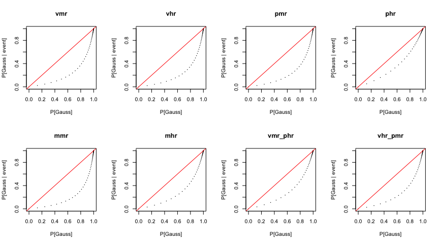

Use $1 - \text{p-value}$ from Lilliefors test as prior probability that the distribution is Gaussian.  
$x_{\text{obs}} = \min(x)$ and $P[\text{Event}\ |\ \text{Gaussian}] = P_{\text{Gauss}}[X \leq x_{\text{min}}]$:

|  | vmr | vhr | pmr | phr | mmr | mhr | vmr_phr | vhr_pmr |
| --- | --- | --- | --- | --- | --- | --- | --- | --- |
| Lillie p-val | 0.052 | 0.343 | 0.024 | 0.060 | 0.041 | 0.251 | 0.113 | 0.183 |
| Prior prob | 0.948 | 0.657 | 0.976 | 0.940 | 0.959 | 0.749 | 0.887 | 0.817 |
| P[Gauss \| Event] | 0.737 | 0.210 | 0.855 | 0.852 | 0.730 | 0.383 | 0.649 | 0.448 |

Use $1 - \text{p-value}$ from Lilliefors test as prior probability that the distribution is Gaussian.  
$x_{\text{obs}} = \max(x)$ and $P[\text{Event}\ |\ \text{Gaussian}] = P_{\text{Gauss}}[X \geq x_{\text{max}}]$:

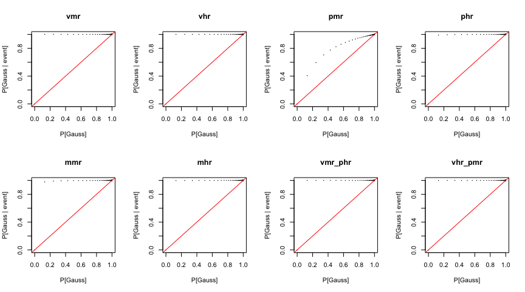

|  | vmr | vhr | pmr | phr | mmr | mhr | vmr_phr | vhr_pmr |
| --- | --- | --- | --- | --- | --- | --- | --- | --- |
| Lillie p-val | 0.052 | 0.343 | 0.024 | 0.06 | 0.041 | 0.251 | 0.113 | 0.183 |
| Prior prob | 0.948 | 0.657 | 0.976 | 0.94 | 0.959 | 0.749 | 0.887 | 0.817 |
| P[Gauss \| Event] | 1.000 | 1.000 | 0.995 | 1.00 | 1.000 | 1.000 | 1.000 | 1.000 |

# Velliv medium risk (vmr), 2011 - 2023

## QQ Plot

Skewed $t$-distribution (sstd):

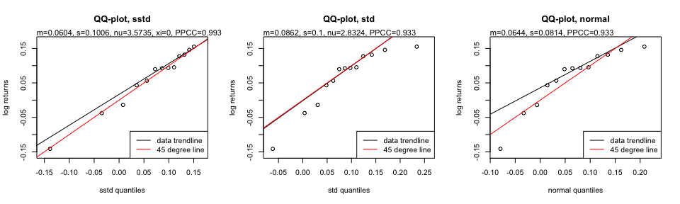

## Data vs fit

Let’s plot the fit and the observed returns together.

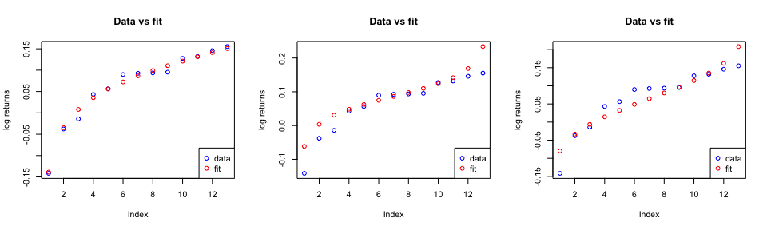

## Estimated distribution

Now lets look at the CDF of the estimated distribution for each 0.1% increment between 0.5% and 99.5% for the estimated distribution:

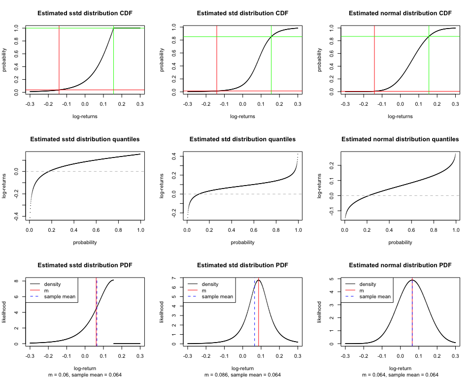

## Monte Carlo

Sorted portfolio index values for last period of all runs

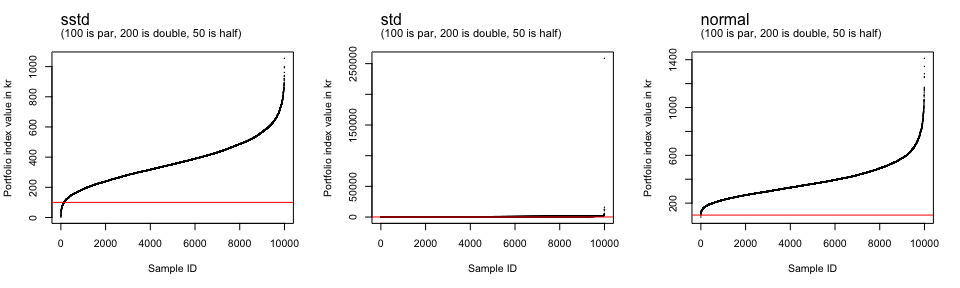

## Convergence

### Max vs sum

Max-vs-sum plots for the first four moments – a ratio that doesn’t fall toward zero flags that moment as possibly non-existent (see “Max-sum plots” in the comparison report for what this diagnostic tests). Panels by fitted distribution:

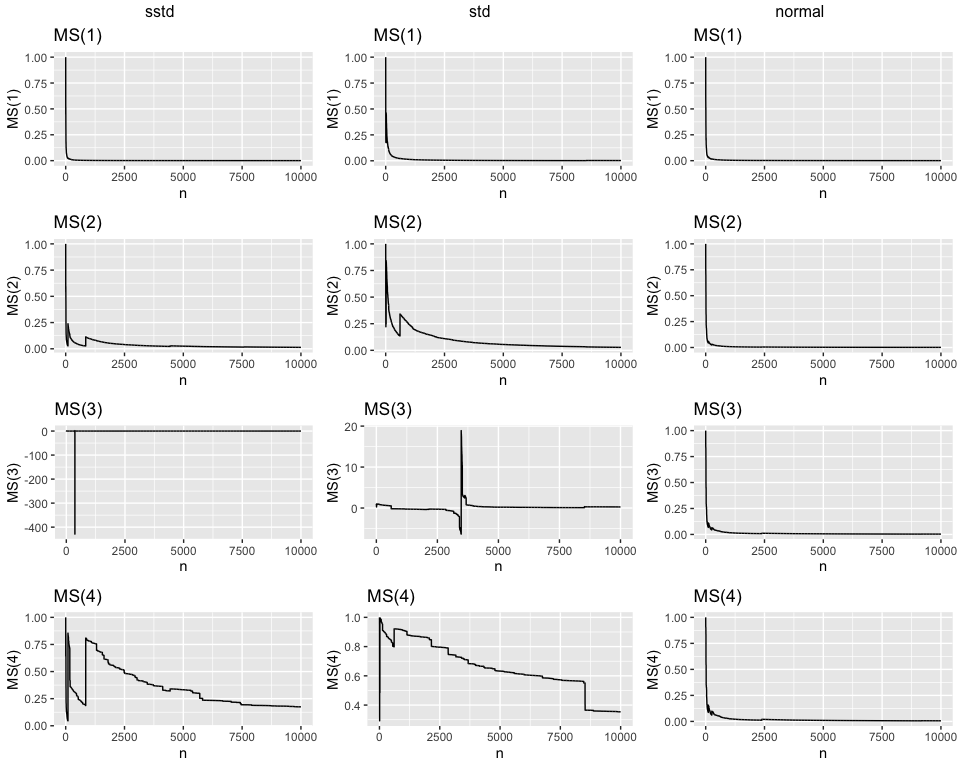

### MC

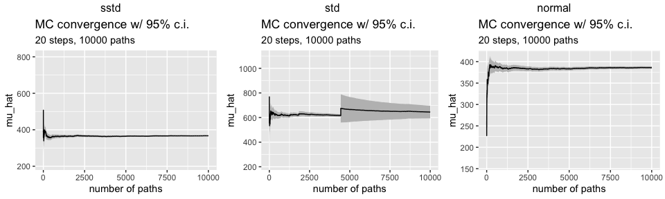

### IS

Skewed $t$-distribution with a normal proposal distribution.

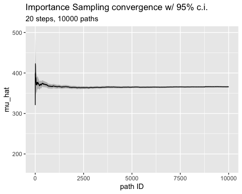

Parameters

```
## [1] 1.3814456 0.4037569
```

Objective function plots

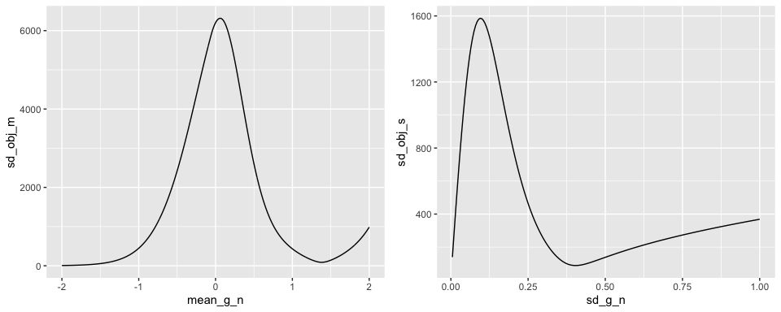

# Velliv high risk (vhr), 2011 - 2023

## QQ Plot

Skewed $t$-distribution (sstd):

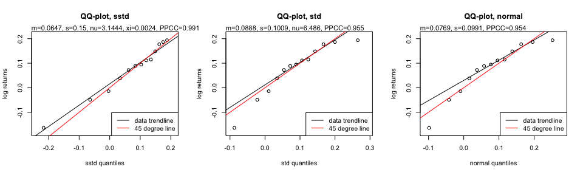

## Data vs fit

Let’s plot the fit and the observed returns together.

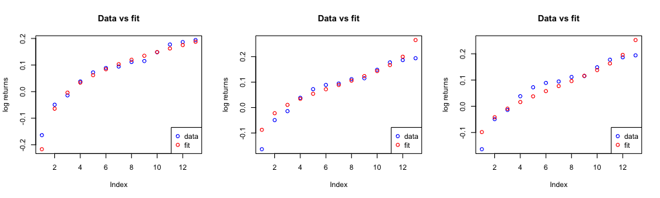

## Estimated distribution

Now lets look at the CDF of the estimated distribution for each 0.1% increment between 0.5% and 99.5% for the estimated distribution:

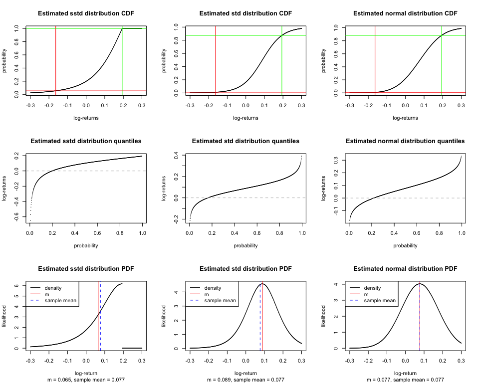

## Monte Carlo

Sorted portfolio index values for last period of all runs

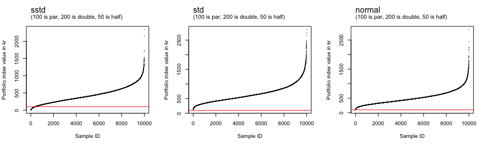

## Convergence

### Max vs sum

Max-vs-sum plots for the first four moments – a ratio that doesn’t fall toward zero flags that moment as possibly non-existent (see “Max-sum plots” in the comparison report for what this diagnostic tests). Panels by fitted distribution:

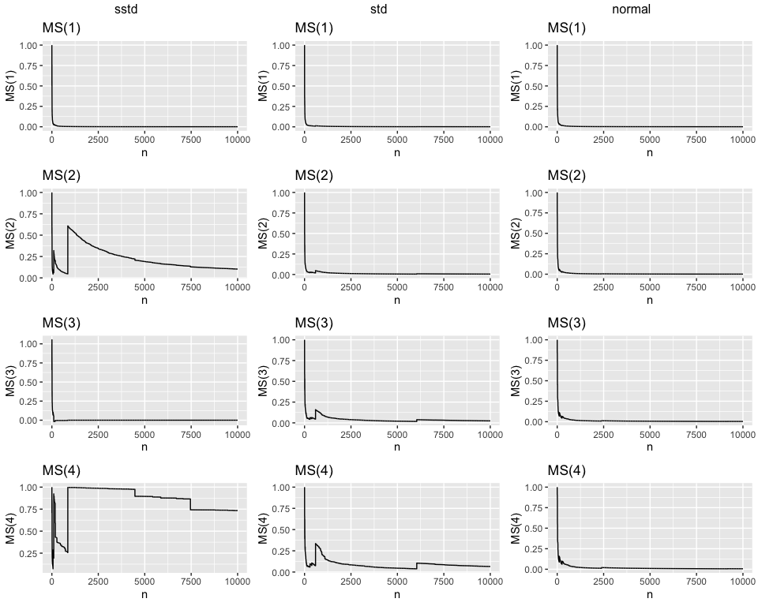

### MC

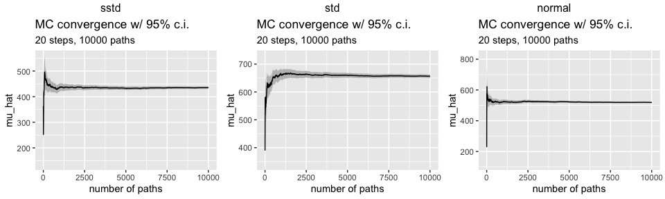

### IS

Skewed $t$-distribution with a normal proposal distribution.

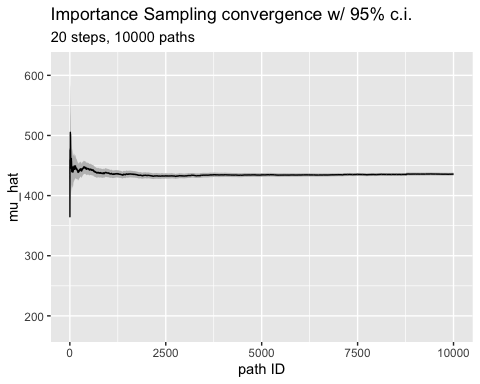

Parameters

```
## [1] 1.6232606 0.5374871
```

Objective function plots

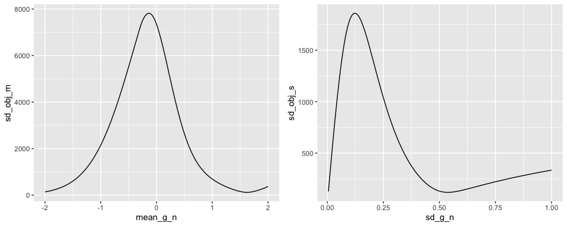

# PFA medium risk (pmr), 2011 - 2023

## QQ Plot

Skewed $t$-distribution (sstd):

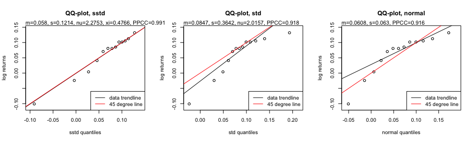

## Data vs fit

Let’s plot the fit and the observed returns together.

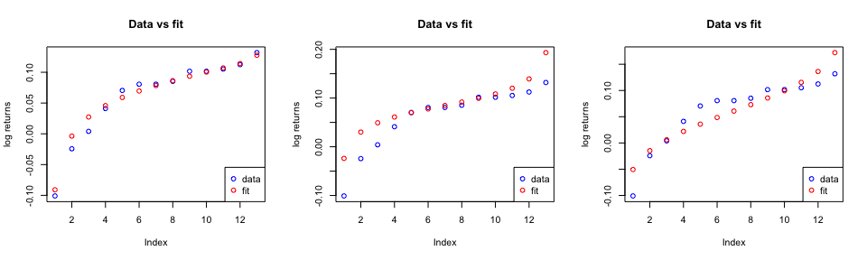

## Estimated distribution

Now lets look at the CDF of the estimated distribution for each 0.1% increment between 0.5% and 99.5% for the estimated distribution:

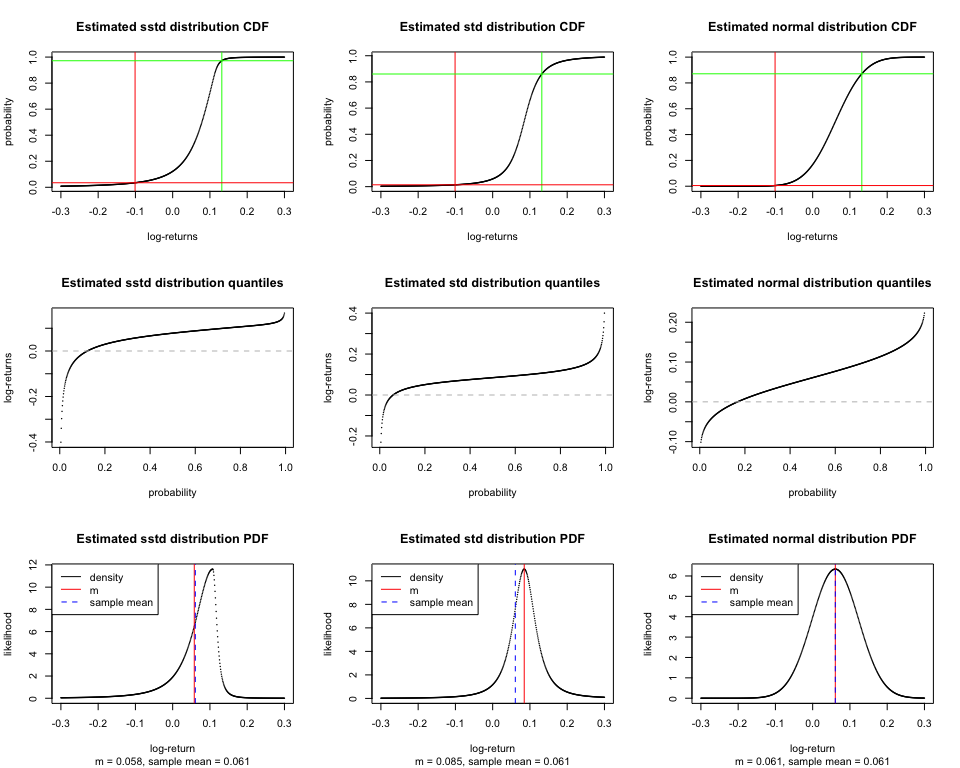

## Monte Carlo

pmr has the sstd fit with the lowest value of nu. Compare with other distributions:

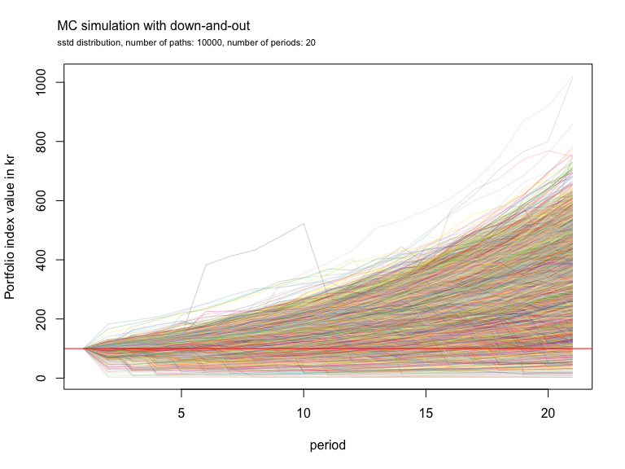

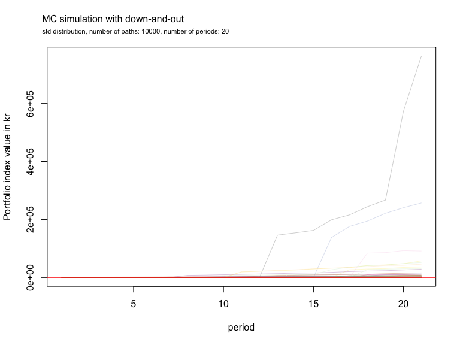

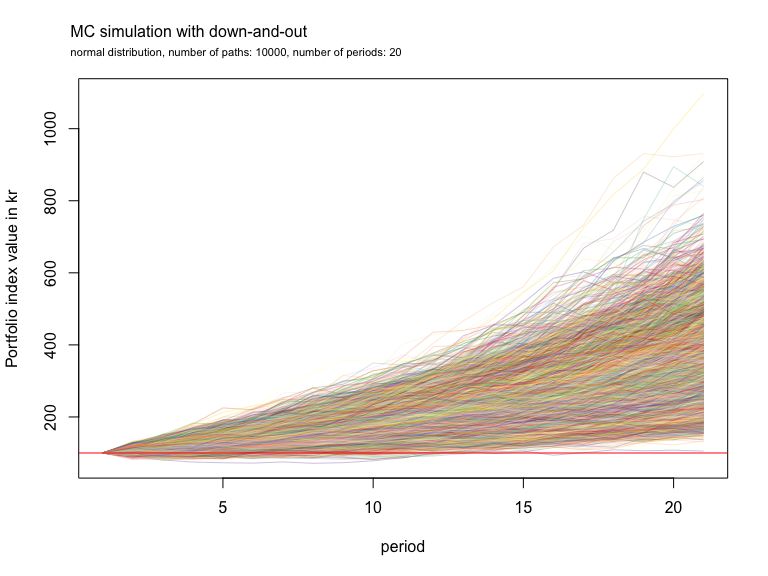

Sorted portfolio index values for last period of all runs

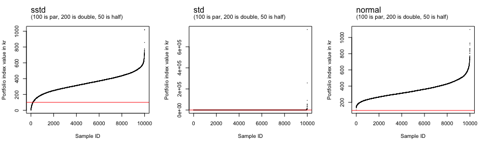

## Convergence

### Max vs sum

Max-vs-sum plots for the first four moments – a ratio that doesn’t fall toward zero flags that moment as possibly non-existent (see “Max-sum plots” in the comparison report for what this diagnostic tests). Panels by fitted distribution:

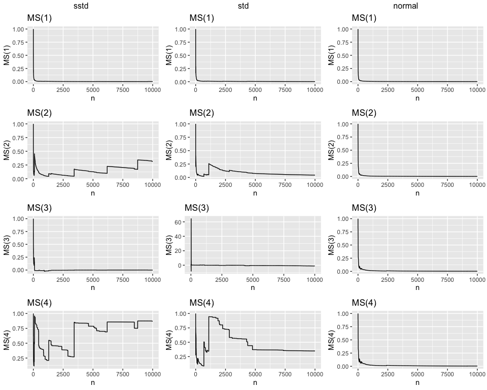

### MC

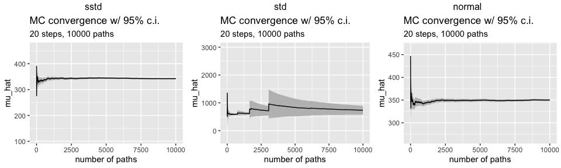

### IS

Skewed $t$-distribution with a normal proposal distribution.

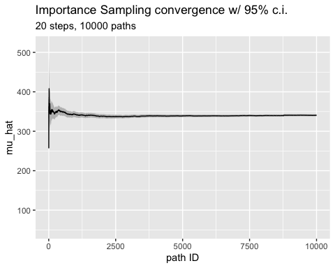

Parameters

```
## [1] 1.2899115 0.3384805
```

Objective function plots

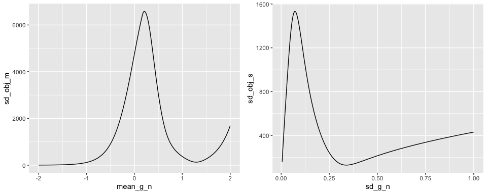